# Keith Wampler

## Task 5: Model Comparison and Reflection

Which model would you choose for predicting log-income on new ACS data: the XGBoost model from Task 3 or the neural network from Task 4? Why?

**Answer:**

I would choose the XGBoost model due to its lower RMSE on the validation set compared to the neural network. I did make sure to convert the neural net MSE to RMSE for a fair comparison. Both models generated a tigher distrituon than the actual log income values.

```python
from sklearn.metrics import mean_squared_error

# 1. Ensure y_test and predictions are flattened (1D arrays) for accurate calculation
y_true = y_test.flatten()
xgb_preds = y_pred_xgb.flatten()
nn_preds = best_model.predict(x_test, verbose=0).flatten() # Recalculate NN preds using the 'best_model'

# 2. Calculate XGBoost RMSE
mse_xgb = mean_squared_error(y_true, xgb_preds)
rmse_xgb = np.sqrt(mse_xgb)

# 3. Calculate Neural Network RMSE
# Even though we trained on MSE, we calculate RMSE here for fair comparison
mse_nn = mean_squared_error(y_true, nn_preds)
rmse_nn = np.sqrt(mse_nn)

# 4. Print Results
print("--- Final Model Comparison ---")
print(f"XGBoost RMSE:        {rmse_xgb:.5f}")
print(f"Neural Network RMSE: {rmse_nn:.5f}")

if rmse_xgb < rmse_nn:
    print(f"\nWinner: XGBoost (by {rmse_nn - rmse_xgb:.5f})")
else:
    print(f"\nWinner: Neural Network (by {rmse_nn - rmse_xgb:.5f})")
```

```
--- Final Model Comparison ---
XGBoost RMSE:        0.79986
Neural Network RMSE: 0.87349

Winner: XGBoost (by 0.07363)
```

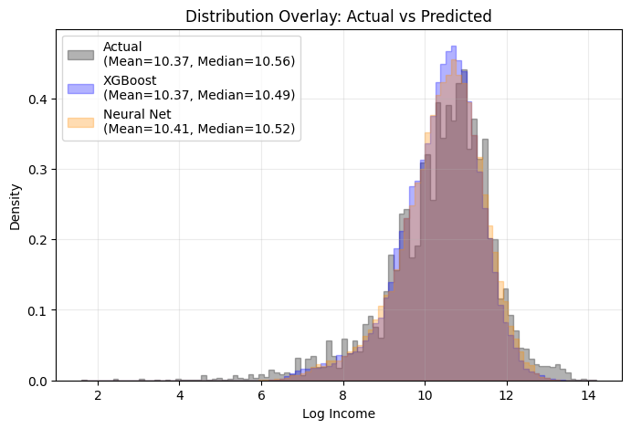

```python
import seaborn as sns

# Overlay histograms of actual vs XGBoost vs Neural Network (log-income)
vals = {
    "Actual": y_true,
    "XGBoost": xgb_preds,
    "Neural Net": nn_preds
}

# Setup Plot (Small Size)
plt.figure(figsize=(8, 5))

# High Contrast Colors
colors = {"Actual": "black", "XGBoost": "blue", "Neural Net": "darkorange"}

# Bins
lo = min(arr.min() for arr in vals.values())
hi = max(arr.max() for arr in vals.values())
bins = np.linspace(lo, hi, 100)

for name, arr in vals.items():
    # Calculate Metrics
    mu = arr.mean()
    med = np.median(arr)

    # Create Label with Metrics included
    label_text = f"{name}\n(Mean={mu:.2f}, Median={med:.2f})"

    # Plot Histogram Only (No vertical lines)
    plt.hist(arr, bins=bins, density=True, alpha=0.3,
             label=label_text, color=colors[name],
             histtype='stepfilled', edgecolor=colors[name])

plt.xlabel("Log Income")
plt.ylabel("Density")
plt.title("Distribution Overlay: Actual vs Predicted")
plt.legend(loc='upper left')
plt.grid(alpha=0.25)
plt.show()
```

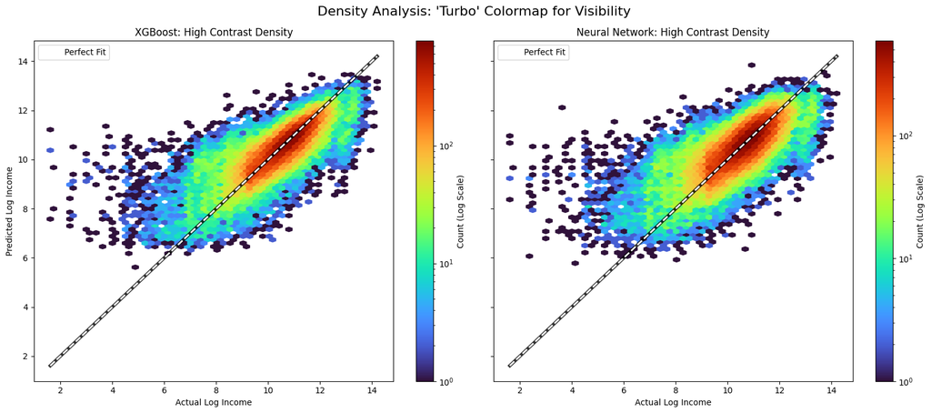

```python
# Setup Figure
fig, axes = plt.subplots(1, 2, figsize=(16, 7), sharey=True)

# Gridsize and Colormap
grid = 50
# 'turbo' provides high contrast rainbows (Blue=Low, Red=High Density)
cmap = 'turbo'

# --- Plot 1: XGBoost Hexbin ---
hb1 = axes[0].hexbin(y_true, xgb_preds, gridsize=grid, cmap=cmap, mincnt=1, bins='log')

# High-Contrast "Perfect Fit" Line (White with Black Outline)
axes[0].plot([y_true.min(), y_true.max()], [y_true.min(), y_true.max()], 'k-', lw=4, alpha=0.8) # Outline
axes[0].plot([y_true.min(), y_true.max()], [y_true.min(), y_true.max()], 'w--', lw=2, label='Perfect Fit')

axes[0].set_title("XGBoost: High Contrast Density")
axes[0].set_xlabel("Actual Log Income")
axes[0].set_ylabel("Predicted Log Income")
axes[0].legend(loc='upper left')

# Add Colorbar for Plot 1
cb1 = fig.colorbar(hb1, ax=axes[0])
cb1.set_label('Count (Log Scale)')

# --- Plot 2: Neural Network Hexbin ---
hb2 = axes[1].hexbin(y_true, nn_preds, gridsize=grid, cmap=cmap, mincnt=1, bins='log')

# High-Contrast "Perfect Fit" Line
axes[1].plot([y_true.min(), y_true.max()], [y_true.min(), y_true.max()], 'k-', lw=4, alpha=0.8) # Outline
axes[1].plot([y_true.min(), y_true.max()], [y_true.min(), y_true.max()], 'w--', lw=2, label='Perfect Fit')

axes[1].set_title("Neural Network: High Contrast Density")
axes[1].set_xlabel("Actual Log Income")
axes[1].legend(loc='upper left')

# Add Colorbar for Plot 2
cb2 = fig.colorbar(hb2, ax=axes[1])
cb2.set_label('Count (Log Scale)')

plt.suptitle("Density Analysis: 'Turbo' Colormap for Visibility", fontsize=16)
plt.tight_layout()
plt.show()
```

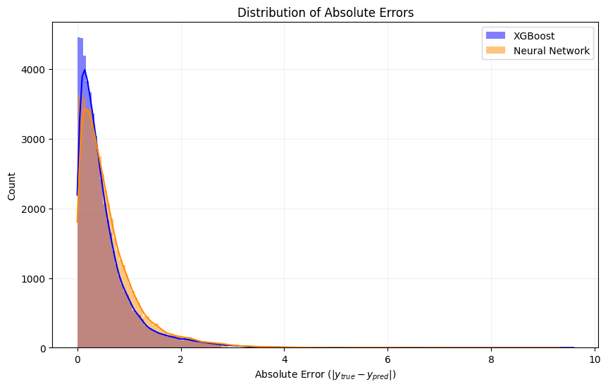

```python
# 1. Calculate Absolute Errors
xgb_err = np.abs(y_true - xgb_preds)
nn_err = np.abs(y_true - nn_preds)

# 2. Determine Zoom Limits (99th percentile)
xgb_err_zoom_limit = np.percentile(xgb_err, 99)
nn_err_zoom_limit = np.percentile(nn_err, 99)

# 3. Create a DataFrame for Visualization
df_err = pd.DataFrame({
    'XGBoost Error': xgb_err,
    'Neural Net Error': nn_err
})

# 4. Plotting (Example for comparison)
plt.figure(figsize=(10, 6))

# Histogram 1: XGBoost Error
sns.histplot(df_err['XGBoost Error'], bins=50, kde=True, label='XGBoost', color='blue',
             edgecolor='none', alpha=0.5, ax=plt.gca(),
             binrange=(0, xgb_err_zoom_limit))

# Histogram 2: Neural Network Error
sns.histplot(df_err['Neural Net Error'], bins=50, kde=True, label='Neural Network', color='darkorange',
             edgecolor='none', alpha=0.5, ax=plt.gca(),
             binrange=(0, nn_err_zoom_limit))

plt.title('Distribution of Absolute Errors')
plt.xlabel('Absolute Error ($|y_{true} - y_{pred}|$)')
plt.ylabel('Count')
plt.legend()
plt.grid(alpha=0.2)
plt.show()
```

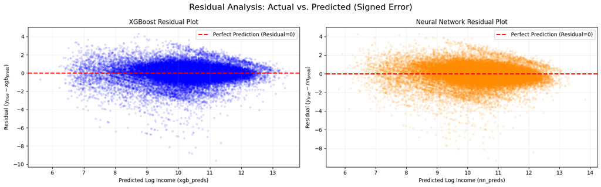

```python
# 1. Calculate Signed Residuals (Actual - Predicted)

xgb_resid = y_true - xgb_preds
nn_resid = y_true - nn_preds

# 2. Setup Data for Plotting (Example using a scatter plot for residuals)
plt.figure(figsize=(16, 5))

# --- Plot 1: XGBoost Residuals ---
plt.subplot(1, 2, 1)
plt.scatter(xgb_preds, xgb_resid, alpha=0.1, s=10, color='blue')
plt.axhline(0, color='red', linestyle='--', linewidth=2, label='Perfect Prediction (Residual=0)')
plt.title('XGBoost Residual Plot')
plt.xlabel('Predicted Log Income (xgb_preds)')
plt.ylabel('Residual ($y_{true} - xgb_{preds}$)')
plt.legend()
plt.grid(alpha=0.2)

# --- Plot 2: Neural Network Residuals ---
plt.subplot(1, 2, 2)
plt.scatter(nn_preds, nn_resid, alpha=0.1, s=10, color='darkorange')
plt.axhline(0, color='red', linestyle='--', linewidth=2, label='Perfect Prediction (Residual=0)')
plt.title('Neural Network Residual Plot')
plt.xlabel('Predicted Log Income (nn_preds)')
plt.ylabel('Residual ($y_{true} - nn_{preds}$)')
plt.legend()
plt.grid(alpha=0.2)

plt.suptitle('Residual Analysis: Actual vs. Predicted (Signed Error)', fontsize=16)
plt.tight_layout()
plt.show()
```

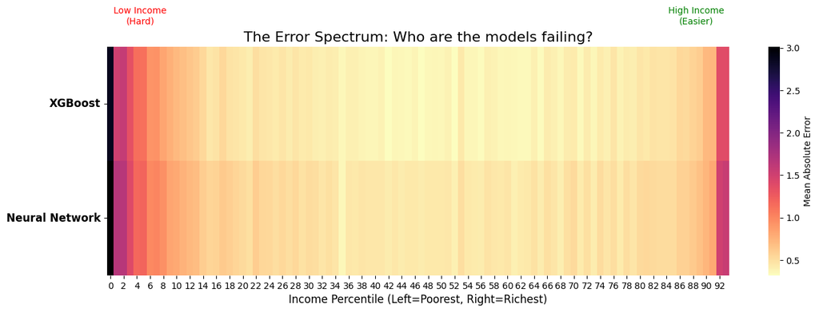

```python
import matplotlib.pyplot as plt
import numpy as np
import pandas as pd
import seaborn as sns

# --- STEP 1: ensure data exists and is flat ---
try:
    # Try to use existing flat arrays
    y_test_flat = y_test.flatten()
    y_pred_xgb_flat = y_pred_xgb.flatten()
    y_pred_nn_flat = y_pred_nn.flatten()
except NameError:
    print("Error: Variables not found. Please re-run the training/prediction steps.")
    # Stop execution here if data is missing to avoid confusing errors below
    raise

# --- STEP 2: Prepare DataFrame ---
df_viz = pd.DataFrame({
    'Actual': y_test_flat,
    'XGB_Error': np.abs(y_test_flat - y_pred_xgb_flat),
    'NN_Error': np.abs(y_test_flat - y_pred_nn_flat)
})

# Sort by Actual Income
df_viz = df_viz.sort_values(by='Actual')

# --- STEP 3: Robust Binning ---
# FIX: Added duplicates='drop' to prevent "Bin edges must be unique" error
df_viz['Percentile'] = pd.qcut(df_viz['Actual'], q=100, labels=False, duplicates='drop')

# Group and pivot
heatmap_data = df_viz.groupby('Percentile')[['XGB_Error', 'NN_Error']].mean().T

# --- STEP 4: Plotting ---
plt.figure(figsize=(14, 5))

# Plot Heatmap
sns.heatmap(heatmap_data, cmap='magma_r', cbar_kws={'label': 'Mean Absolute Error'},
            yticklabels=['XGBoost', 'Neural Network'])

# Beautify Labels
plt.title("The Error Spectrum: Who are the models failing?", fontsize=16)
plt.xlabel("Income Percentile (Left=Poorest, Right=Richest)", fontsize=12)
plt.yticks(rotation=0, fontsize=12, fontweight='bold')

# Add markers for context
plt.text(5, -0.2, "Low Income\n(Hard)", ha='center', color='red', fontsize=10)
plt.text(heatmap_data.shape[1]-5, -0.2, "High Income\n(Easier)", ha='center', color='green', fontsize=10)

plt.tight_layout()
plt.show()
```